# Lab 7

```python
# import library
import pickle
import numpy as np
from matplotlib import pyplot as plt
from scipy.stats import poisson
from scipy.stats import norm

# open the file of interest, and use pickle loading
infile = open ("qcd_100000_pt_250_500.pkl",'rb')
qcd = pickle.load(infile)
infile = open ("higgs_100000_pt_250_500.pkl",'rb')
higg = pickle.load(infile)
# list all keys of the files
#print(qcd.keys())
#print(higg.keys())
plt.rcParams["figure.figsize"] = (15,12)
```

## 1

Make a stacked histogram plot for the feature variable: mass Evaluate expected significance without any event selection.

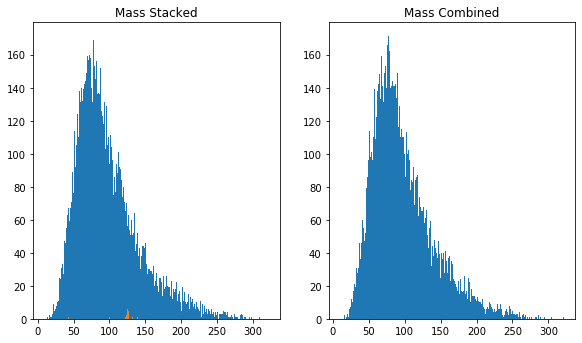

```
5 sigma detection boundry = 20711.0
significance (poisson) = 0.7112259282313185
significance (N/sqrt(N)) = 0.7071067811865475
```

```python
qcd_mass = qcd['mass']
higg_mass = higg['mass']
plt.subplot(2, 3, 1)
plt.hist(qcd_mass[0:20000],500)
plt.title('Mass Stacked')
plt.hist(higg_mass[0:100],500)
plt.subplot(2, 3, 2)
combined = np.append(qcd_mass[0:20000],higg_mass[0:100])
plt.hist(combined,500)
plt.title('Mass Combined')
plt.show()
mu = 20000
sig1 = poisson.ppf((norm.cdf(5)),mu)
sig2 = abs(norm.ppf(1-poisson.cdf(20100,mu)))
print("5 sigma detection boundry =",sig1)
print("significance (poisson) =",sig2)
sig3 = 100/(np.sqrt(20000))
print("significance (N/sqrt(N)) =", sig3)
```

Above we can see that, with a random selection and no event selection, we can only get a sigma of 0.7 by counting # of events.

On a side note, the two methods of calculating significance gave very very similiar results.

## 2

Identify mass cuts to optimize the expected significance.

Below we have cuts of increasing specificity and resulting in higher and higher significance. alothough notably, even a cut with a width of 1 only gave a significance of ~3.2

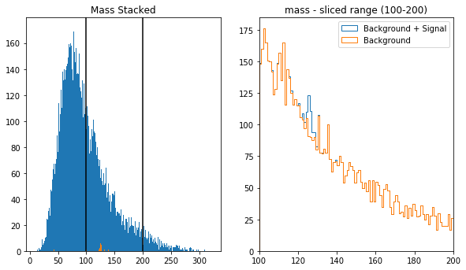

```
5 sigma detection boundry = 7469.0
significance (poisson) = 1.1016326913845593
significance (N/sqrt(N)) = 1.0960928092163993
```

```python
qcd_mass = qcd['mass']
higg_mass = higg['mass']
qcd_hist = plt.hist(qcd_mass[0:20000],1,histtype = 'step',range = (100,200))
comb_hist = plt.hist(combined,1,histtype = 'step',range = (100,200))
plt.subplot(2, 3, 1)
plt.hist(qcd_mass[0:20000],500)
plt.title('Mass Stacked')
plt.hist(higg_mass[0:100],500)
plt.axvline(x=100,color = "black")
plt.axvline(x=200,color = "black")

plt.subplot(2, 3, 2)
plt.hist(combined,100,histtype = 'step',range = (100,200),label = "Background + Signal")
plt.hist(qcd_mass[0:20000],100,histtype = 'step',range = (100,200),label = "Background")
plt.title('mass - sliced range (100-200)')
plt.xlim(100,200)

plt.legend()

plt.show()

ccc = comb_hist[0]
bbb = qcd_hist[0]
mu = bbb[0]
sigsize = ccc[0]

sig1 = poisson.ppf((norm.cdf(5)),mu)
sig2 = abs(norm.ppf(1-poisson.cdf((sigsize),mu)))
print("5 sigma detection boundry =",sig1)
print("significance (poisson) =",sig2)
sig3 = (sigsize-mu)/(np.sqrt(mu))
print("significance (N/sqrt(N)) =", sig3)
```

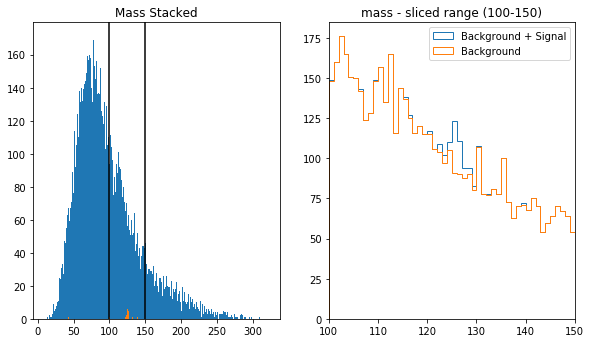

```
5 sigma detection boundry = 5598.0
significance (poisson) = 1.2773722264621865
significance (N/sqrt(N)) = 1.2719029063014613
```

```python
qcd_mass = qcd['mass']
higg_mass = higg['mass']
qcd_hist = plt.hist(qcd_mass[0:20000],1,histtype = 'step',range = (100,150))
comb_hist = plt.hist(combined,1,histtype = 'step',range = (100,150))
plt.subplot(2, 3, 1)
plt.hist(qcd_mass[0:20000],500)
plt.title('Mass Stacked')
plt.hist(higg_mass[0:100],500)
plt.axvline(x=100,color = "black")
plt.axvline(x=150,color = "black")

plt.subplot(2, 3, 2)
plt.hist(combined,50,histtype = 'step',range = (100,150),label = "Background + Signal")
plt.hist(qcd_mass[0:20000],50,histtype = 'step',range = (100,150),label = "Background")
plt.title('mass - sliced range (100-150)')
plt.xlim(100,150)
plt.legend()
plt.show()

ccc = comb_hist[0]
bbb = qcd_hist[0]
mu = bbb[0]
sigsize = ccc[0]

sig1 = poisson.ppf((norm.cdf(5)),mu)
sig2 = abs(norm.ppf(1-poisson.cdf((sigsize),mu)))
print("5 sigma detection boundry =",sig1)
print("significance (poisson) =",sig2)
sig3 = (sigsize-mu)/(np.sqrt(mu))
print("significance (N/sqrt(N)) =", sig3)
```

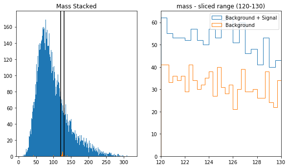

```
5 sigma detection boundry = 1125.0
significance (poisson) = 2.654483759573351
significance (N/sqrt(N)) = 2.6704812261643154
```

```python
qcd_mass = qcd['mass']
higg_mass = higg['mass']
qcd_hist = plt.hist(qcd_mass[0:20000],1,histtype = 'step',range = (120,130))
comb_hist = plt.hist(combined,1,histtype = 'step',range = (120,130))
plt.subplot(2, 3, 1)
plt.hist(qcd_mass[0:20000],500)
plt.title('Mass Stacked')
plt.hist(higg_mass[0:100],500)
plt.axvline(x=120,color = "black")
plt.axvline(x=130,color = "black")

plt.subplot(2, 3, 2)
plt.hist(combined,20,histtype = 'step',range = (120,130),label = "Background + Signal")
plt.hist(qcd_mass[0:20000],30,histtype = 'step',range = (120,130),label = "Background")
plt.title('mass - sliced range (120-130)')
plt.xlim(120,130)
plt.legend()
plt.show()

ccc = comb_hist[0]
bbb = qcd_hist[0]
mu = bbb[0]
sigsize = ccc[0]

sig1 = poisson.ppf((norm.cdf(5)),mu)
sig2 = abs(norm.ppf(1-poisson.cdf((sigsize),mu)))
print("5 sigma detection boundry =",sig1)
print("significance (poisson) =",sig2)
sig3 = (sigsize-mu)/(np.sqrt(mu))
print("significance (N/sqrt(N)) =", sig3)
```

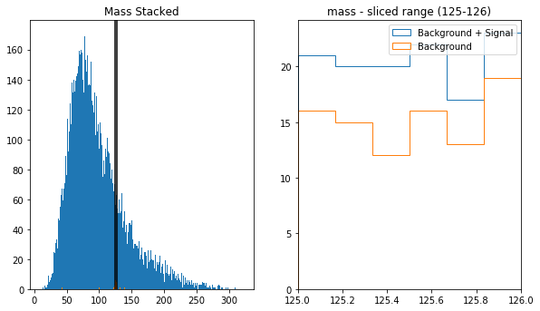

```
5 sigma detection boundry = 143.0
significance (poisson) = 3.246020108883621
significance (N/sqrt(N)) = 3.3545114775101386
```

```python
qcd_mass = qcd['mass']
higg_mass = higg['mass']
qcd_hist = plt.hist(qcd_mass[0:20000],1,histtype = 'step',range = (125,126))
comb_hist = plt.hist(combined,1,histtype = 'step',range = (125,126))
plt.subplot(2, 3, 1)
plt.hist(qcd_mass[0:20000],500)
plt.title('Mass Stacked')
plt.hist(higg_mass[0:100],500)
plt.axvline(x=125,color = "black")
plt.axvline(x=127,color = "black")

plt.subplot(2, 3, 2)
plt.hist(combined,6,histtype = 'step',range = (125,126),label = "Background + Signal")
plt.hist(qcd_mass[0:20000],6,histtype = 'step',range = (125,126),label = "Background")
plt.title('mass - sliced range (125-126)')
plt.xlim(125,126)
plt.legend()
plt.show()

ccc = comb_hist[0]
bbb = qcd_hist[0]
mu = bbb[0]
sigsize = ccc[0]

sig1 = poisson.ppf((norm.cdf(5)),mu)
sig2 = abs(norm.ppf(1-poisson.cdf((sigsize),mu)))
print("5 sigma detection boundry =",sig1)
print("significance (poisson) =",sig2)
sig3 = (sigsize-mu)/(np.sqrt(mu))
print("significance (N/sqrt(N)) =", sig3)
```

## 3

Make stacked histogram plots for the rest of the features

Set A of plots without any event selection

- Can you identify another feature as discriminative as mass feature (i.e. equal or better significance after feature cut)

Set B of plots with your optimal mass cuts

- Can you identify additional feature to further imrpove expected signifiance?

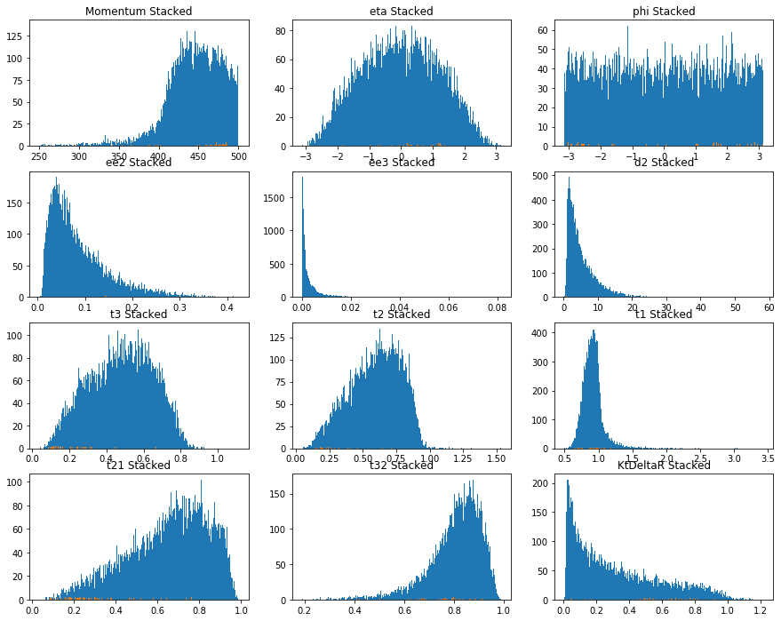

```python
qcd_pt = qcd['pt']
higg_pt = higg['pt']
plt.subplot(4, 3, 1)
plt.hist(qcd_pt[0:20000],500)
plt.title('Momentum Stacked')
plt.hist(higg_pt[0:100],500)

qcd_eta = qcd['eta']
higg_eta = higg['eta']
plt.subplot(4, 3, 2)
plt.hist(qcd_eta[0:20000],500)
plt.title('eta Stacked')
plt.hist(higg_eta[0:100],500)

qcd_phi = qcd['phi']
higg_phi = higg['phi']
plt.subplot(4, 3, 3)
plt.hist(qcd_phi[0:20000],500)
plt.title('phi Stacked')
plt.hist(higg_phi[0:100],500)

qcd_ee2 = qcd['ee2']
higg_ee2 = higg['ee2']
plt.subplot(4, 3, 4)
plt.hist(qcd_ee2[0:20000],500)
plt.title('ee2 Stacked')
plt.hist(higg_ee2[0:100],500)

qcd_ee3 = qcd['ee3']
higg_ee3 = higg['ee3']
plt.subplot(4, 3, 5)
plt.hist(qcd_ee3[0:20000],500)
plt.title('ee3 Stacked')
plt.hist(higg_ee3[0:100],500)

qcd_d2 = qcd['d2']
higg_d2 = higg['d2']
plt.subplot(4, 3, 6)
plt.hist(qcd_d2[0:20000],500)
plt.title('d2 Stacked')
plt.hist(higg_d2[0:100],500)

qcd_t3 = qcd['t3']
higg_t3 = higg['t3']
plt.subplot(4, 3, 7)
plt.hist(qcd_t3[0:20000],500)
plt.title('t3 Stacked')
plt.hist(higg_t3[0:100],500)

qcd_t2 = qcd['t2']
higg_t2 = higg['t2']
plt.subplot(4, 3, 8)
plt.hist(qcd_t2[0:20000],500)
plt.title('t2 Stacked')
plt.hist(higg_t2[0:100],500)

qcd_t1 = qcd['t1']
higg_t1 = higg['t1']
plt.subplot(4, 3, 9)
plt.hist(qcd_t1[0:20000],500)
plt.title('t1 Stacked')
plt.hist(higg_t1[0:100],500)

qcd_t21 = qcd['t21']
higg_t21 = higg['t21']
plt.subplot(4, 3, 10)
plt.hist(qcd_t21[0:20000],500)
plt.title('t21 Stacked')
plt.hist(higg_t21[0:100],500)

qcd_t32 = qcd['t32']
higg_t32 = higg['t32']
plt.subplot(4, 3, 11)
plt.hist(qcd_t32[0:20000],500)
plt.title('t32 Stacked')
plt.hist(higg_t32[0:100],500)

qcd_KtDeltaR = qcd['KtDeltaR']
higg_KtDeltaR = higg['KtDeltaR']
plt.subplot(4, 3, 12)
plt.hist(qcd_KtDeltaR[0:20000],500)
plt.title('KtDeltaR Stacked')
plt.hist(higg_KtDeltaR[0:100],500)

plt.show()
```

Above is Set A, None of the above apear to be as discriminitive as mass. We will have to make the mass cuts first to see if any are particularly viable.

```python
qcdm = qcd[0:20000]
higgm = higg[0:100]
higgh = higgm[higgm["mass"] >= 125]
qcdh = qcdm[qcdm["mass"] >= 125]
higgl = higgh[higgh["mass"] <= 126]
qcdl = qcdh[qcdh["mass"] <= 126]
#print(higgl)
#print(qcdl)
```

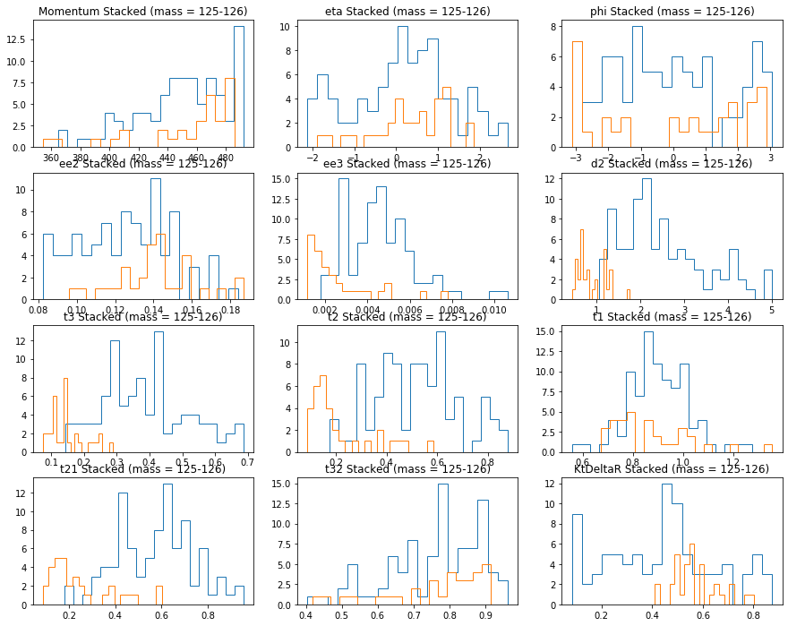

```python
binsize = 20

plt.subplot(4, 3, 1)
plt.hist(qcdl['pt'],binsize,histtype = 'step')
plt.title('Momentum Stacked (mass = 125-126)')
plt.hist(higgl['pt'],binsize,histtype = 'step')


plt.subplot(4, 3, 2)
plt.hist(qcdl['eta'],binsize,histtype = 'step')
plt.title('eta Stacked (mass = 125-126)')
plt.hist(higgl['eta'],binsize,histtype = 'step')


plt.subplot(4, 3, 3)
plt.hist(qcdl['phi'],binsize,histtype = 'step')
plt.title('phi Stacked (mass = 125-126)')
plt.hist(higgl['phi'],binsize,histtype = 'step')

plt.subplot(4, 3, 4)
plt.hist(qcdl['ee2'],binsize,histtype = 'step')
plt.title('ee2 Stacked (mass = 125-126)')
plt.hist(higgl['ee2'],binsize,histtype = 'step')

plt.subplot(4, 3, 5)
plt.hist(qcdl['ee3'],binsize,histtype = 'step')
plt.title('ee3 Stacked (mass = 125-126)')
plt.hist(higgl['ee3'],binsize,histtype = 'step')

plt.subplot(4, 3, 6)
plt.hist(qcdl['d2'],binsize,histtype = 'step')
plt.title('d2 Stacked (mass = 125-126)')
plt.hist(higgl['d2'],binsize,histtype = 'step')

plt.subplot(4, 3, 7)
plt.hist(qcdl['t3'],binsize,histtype = 'step')
plt.title('t3 Stacked (mass = 125-126)')
plt.hist(higgl['t3'],binsize,histtype = 'step')

plt.subplot(4, 3, 8)
plt.hist(qcdl['t2'],binsize,histtype = 'step')
plt.title('t2 Stacked (mass = 125-126)')
plt.hist(higgl['t2'],binsize,histtype = 'step')

plt.subplot(4, 3, 9)
plt.hist(qcdl['t1'],binsize,histtype = 'step')
plt.title('t1 Stacked (mass = 125-126)')
plt.hist(higgl['t1'],binsize,histtype = 'step')

plt.subplot(4, 3, 10)
plt.hist(qcdl['t21'],binsize,histtype = 'step')
plt.title('t21 Stacked (mass = 125-126)')
plt.hist(higgl['t21'],binsize,histtype = 'step')

plt.subplot(4, 3, 11)
plt.hist(qcdl['t32'],binsize,histtype = 'step')
plt.title('t32 Stacked (mass = 125-126)')
plt.hist(higgl['t32'],binsize,histtype = 'step')

plt.subplot(4, 3, 12)
plt.hist(qcdl['KtDeltaR'],binsize,histtype = 'step')
plt.title('KtDeltaR Stacked (mass = 125-126)')
plt.hist(higgl['KtDeltaR'],binsize,histtype = 'step')

plt.show()
```

Above is Set B, after mass cuts (125-126) we can see a few contenders for a second parameter. d2, and t2 catch my eye. their signal peaks near zero seem like they would be a usful range to measure in.

## 4

optimize event selections using multiple features

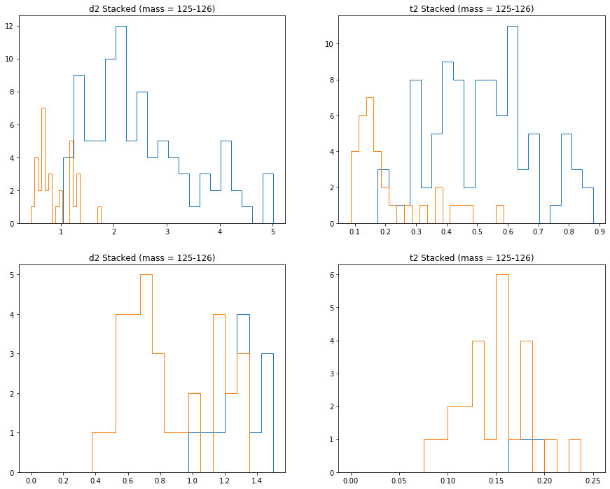

```python
plt.subplot(2, 2, 1)
plt.hist(qcdl['d2'],binsize,histtype = 'step')
plt.title('d2 Stacked (mass = 125-126)')
plt.hist(higgl['d2'],binsize,histtype = 'step')

plt.subplot(2, 2, 2)
plt.hist(qcdl['t2'],binsize,histtype = 'step')
plt.title('t2 Stacked (mass = 125-126)')
plt.hist(higgl['t2'],binsize,histtype = 'step')

plt.subplot(2, 2, 3)
plt.hist(qcdl['d2'],binsize,histtype = 'step',range = (0,1.5))
plt.title('d2 Stacked (mass = 125-126)')
plt.hist(higgl['d2'],binsize,histtype = 'step',range = (0,1.5))

plt.subplot(2, 2, 4)
plt.hist(qcdl['t2'],binsize,histtype = 'step',range = (0,0.25))
plt.title('t2 Stacked (mass = 125-126)')
plt.hist(higgl['t2'],binsize,histtype = 'step',range = (0,0.25))
plt.show()
```

Above are d2, and t2 after the first mass cut. the second row of graphs is showing the second cut near the signle peaks around zero.

This second cut significantly increased the significance of the measurements, up to ~7 sigma in both cases.

```python
#qcd_hist = plt.hist(qcdl['d2'],1,histtype = 'step',range = (0,1.5))
#combined = np.append(higgl['d2'],qcdl['d2'])
#comb_hist = plt.hist(combined,1,histtype = 'step',range = (0,1.5))

ccc = comb_hist[0]
bbb = qcd_hist[0]
mu = bbb[0]
sigsize = ccc[0]

sig1 = poisson.ppf((norm.cdf(5)),mu)
sig2 = abs(norm.ppf(1-poisson.cdf((sigsize),mu)))
print("5 sigma detection boundry =",sig1)
print("significance (poisson) =",sig2)
sig3 = (sigsize-mu)/(np.sqrt(mu))
print("significance (N/sqrt(N)) =", sig3)
```

[output not shown]

```python
#qcd_hist = plt.hist(qcdl['t2'],1,histtype = 'step',range = (0,0.3))
#combined = np.append(higgl['t2'],qcdl['t2'])
#comb_hist = plt.hist(combined,1,histtype = 'step',range = (0,0.3))

ccc = comb_hist[0]
bbb = qcd_hist[0]
mu = bbb[0]
sigsize = ccc[0]

sig1 = poisson.ppf((norm.cdf(5)),mu)
sig2 = abs(norm.ppf(1-poisson.cdf((sigsize),mu)))
print("5 sigma detection boundry =",sig1)
print("significance (poisson) =",sig2)
sig3 = (sigsize-mu)/(np.sqrt(mu))
print("significance (N/sqrt(N)) =", sig3)
```

[output not shown]

[Below is just me playing around with the 2d graphs and paramters]

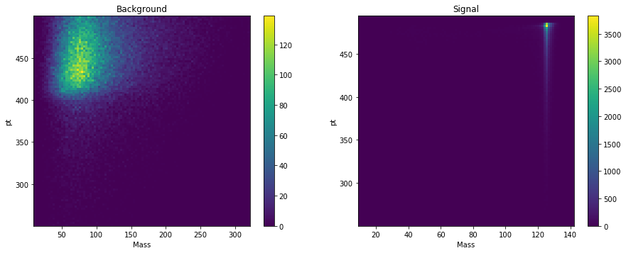

```python
plt.subplot(2, 2, 1)
plt.hist2d(qcd['mass'], qcd['pt'], [100, 100])
plt.title('Background')
plt.xlabel('Mass')
plt.ylabel('pt')
plt.colorbar()

plt.subplot(2, 2, 2)
plt.hist2d(higg['mass'], higg['pt'], [100, 100])
plt.title('Signal')
plt.xlabel('Mass')
plt.ylabel('pt')
plt.colorbar()
```